# Student Mental Health Analysis Using Classification Modeling

2026-03-20

```r
library(caret)
```

```r
library(corrplot)
df <- read.csv("/Users/sarahcampos/Downloads/student_mental_health_burnout_1M.csv")

df$AtRisk <- ifelse(df$risk_level == "High", 1, 0)
df$AtRisk <- as.factor(df$AtRisk)

set.seed(123)
df_sample <- df[sample(nrow(df), 5000), ]
```

# Introduction

Students are increasingly exposed to academic pressure; this poses significant consequences for their mental health. As academic expectations rise, many students experience stress, anxiety and burnout. In turn, this makes it important to identify those who may be at risk. Early identification of vulnerable individuals can support timely interventions and improve overall well-being.(APA) This study examines whether student lifestyle and academic factors can be used to predict mental health risk. Specifically, it seeks to determine whether observable behaviors and academic conditions are sufficient to identify students at risk, or whether psychological indicators provide additional predictive value. By applying classification models, this analysis aims to contribute to a better understanding of how different factors relate to student mental health outcomes.

# Problem Definition and Task

This study is framed as a binary classification problem with the objective to predict whether a student is at risk of poor mental health. The input consists of a set of student-level variables such as lifestyle behaviors, academic conditions, and psychological indicators, while the output is a binary variable representing mental health risk status. A prediction is considered correct if the model accurately classifies a student as either at risk (1) or not at risk (0). This problem presents several challenges, including a high degree of class imbalance, as relatively few students fall into the at-risk category, as well as complex relationships between predictors. Additionally, some variables, particularly psychological measures, are closely related to the outcome itself, making it necessary to carefully interpret their role in the models.

# Model Definition

Three classification approaches are used in this analysis. Logistic regression serves as a baseline model due to its interpretability and its ability to estimate the probability that a student is at risk. This model assumes a linear relationship between the predictors and the log-odds of the outcome. A decision tree model is also employed to capture potential non-linear relationships and interactions between variables by recursively partitioning the data. Finally, a random forest model is implemented as an ensemble method that combines multiple decision trees to improve predictive performance and reduce overfitting. This approach is particularly useful for capturing complex patterns in large datasets.

# Methodology

The primary hypothesis tested in this study is that higher academic workload, measured through study hours and exam pressure, increases the probability that a student is at risk of poor mental health. The dataset used for this analysis contains approximately one million observations, providing a large sample for model training and evaluation. The target variable was constructed from a categorical risk measure and converted into a binary indicator.

To evaluate model performance, the dataset was split into training and testing subsets using a 70/30 split. A 70/30 split is commonly used because it balances the need for sufficient training data with a large enough test set for reliable evaluation.(Gunkurnia) In addition, five-fold cross-validation was applied during model training to improve robustness and reduce overfitting. Since the dataset exhibits severe class imbalance, resampling techniques were applied to ensure that the minority class was adequately represented during training.

Model performance was assessed using accuracy, precision, recall, F1 score, confusion matrices and balanced accuracy. Balanced accuracy is reported as a proportion between 0 and 1 and can be interpreted as a percentage. It is particularly useful in imbalanced datasets because it accounts for performance across both classes equally. Given the imbalance in the data, particular emphasis was placed on recall and balanced accuracy, as these metrics better reflect the model’s ability to identify at-risk students.

# Results

## Distribution of Key Variables

## Histogram of sleep hours

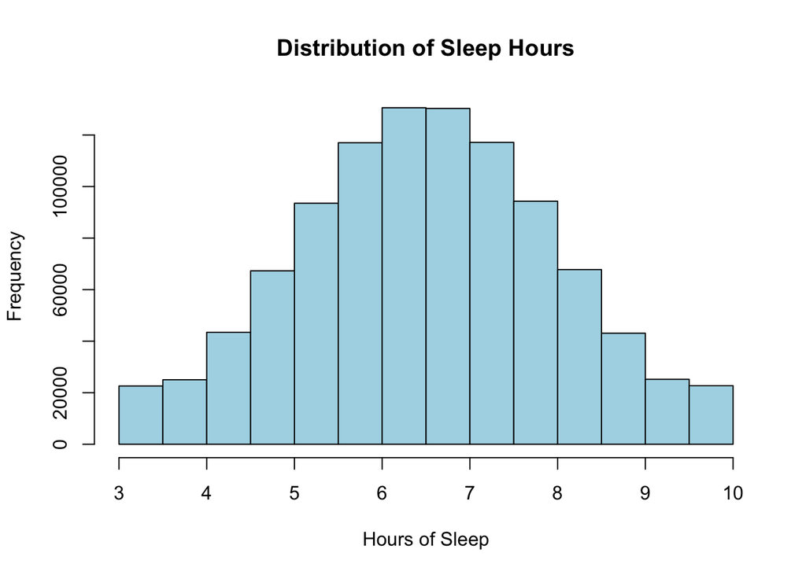

```r
hist(df$sleep_hours,
     main = "Distribution of Sleep Hours",
     xlab = "Hours of Sleep",
     col = "lightblue",
     border = "black")
```

## Histogram of study hours

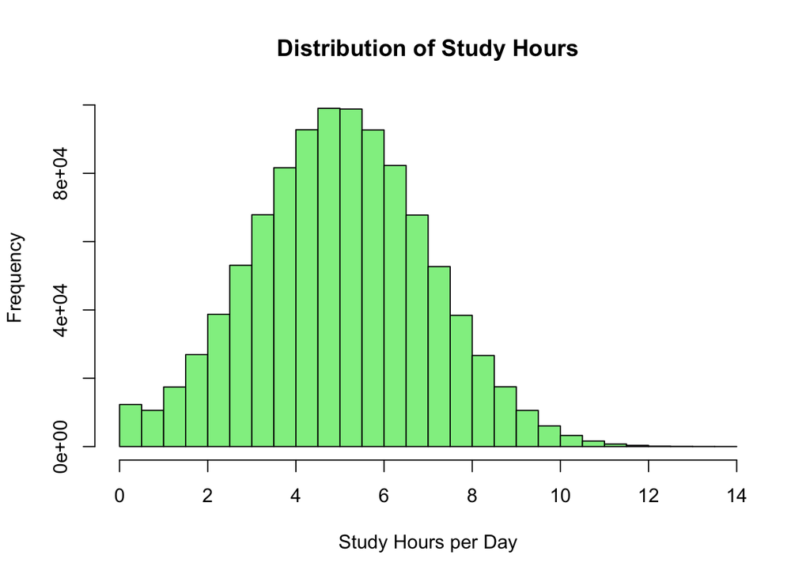

```r
hist(df$study_hours_per_day,
     main = "Distribution of Study Hours",
     xlab = "Study Hours per Day",
     col = "lightgreen",
     border = "black")
```

## Histogram of stress levels

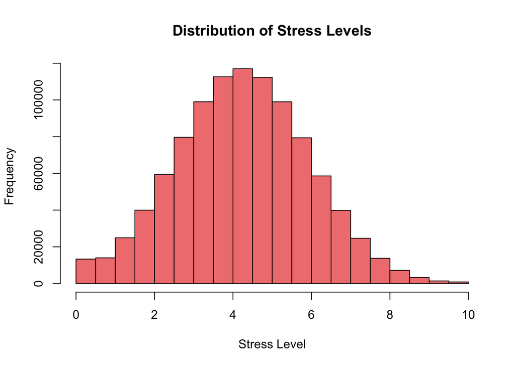

```r
hist(df$stress_level,
     main = "Distribution of Stress Levels",
     xlab = "Stress Level",
     col = "lightcoral",
     border = "black")
```

## Histogram of anxiety scores

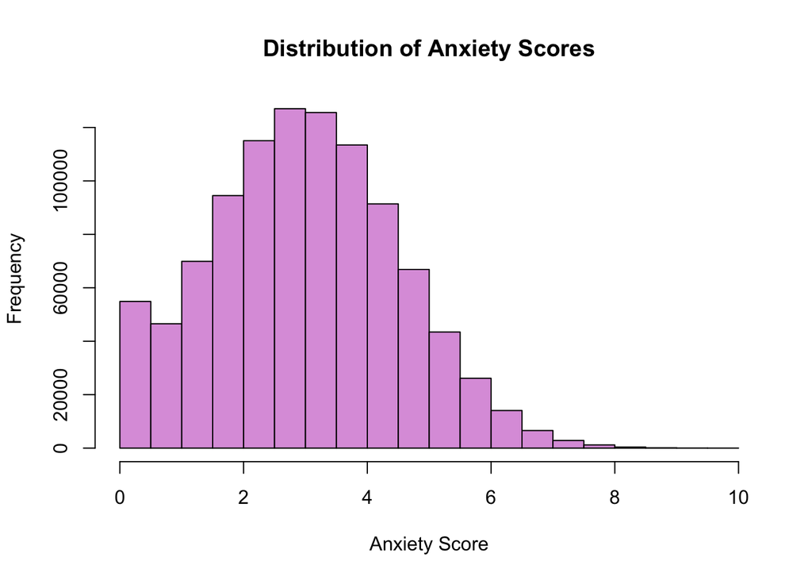

```r
hist(df$anxiety_score,
     main = "Distribution of Anxiety Scores",
     xlab = "Anxiety Score",
     col = "plum",
     border = "black")
```